# Workshop RSO / KTHB

2021-06-01

## Agenda

- ÅBU-appen (10 min)
- Dataflöden (10 min)
- Gruppdiskussion i smågrupper (15 min)
  - Vilka dataset/dataflöden använder du som vore intressanta att samköra med det som visats?
  - Vilka rutinmässiga underlag, analyser och rapporter producerar du som vore intressanta att automatisera?
- Presentation av gruppdiskussion (3 min per grupp)
  - Summering & uppsamlande diskussion

## Bakgrund & bibliometrisk användning

**Exempel på användning av bibliometriska data:**

- Resursfördelning (internationellt, nationellt och inom KTH)
- Ranking
- Uppföljning inom KTH
- RAE
- Projektansökningar

**Leveranser**:

- Rapportunderlag
- ÅBU (app)
- Besvara skräddarsydda analysförfrågningar

## Demo av ÅBU-appen

- Årlig bibliometrisk uppföljning: [ÅBU/ABM](https://kth.se/abm)
- Personalbaserad ÅBU: [authorbased ABM](https://bibliometrics.lib.kth.se/beta/authorbased)

## Data för verksamhetens behov

- Datakällor - Strukturerade data inom och utanför KTH
- Dataflöden - Hur flyttar/reser data inom organisationen eller för olika behov?
- Dataklasser / entiteter - Används som noder vid analys eller för att knyta ihop data
  - **Forskare**
  - **Organisationer på KTH**
  - **Publikationer**
  - **Indikatorer**

## Dataflöden i ÅBU-projektet

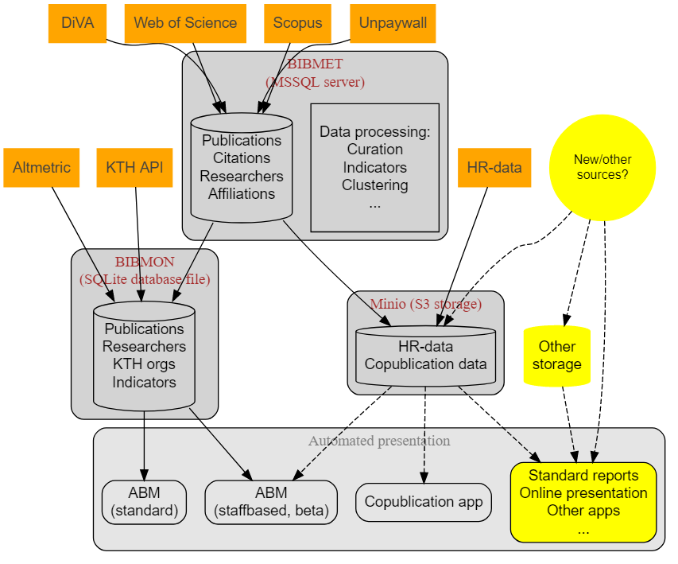

## Andra tillgängliga datakällor

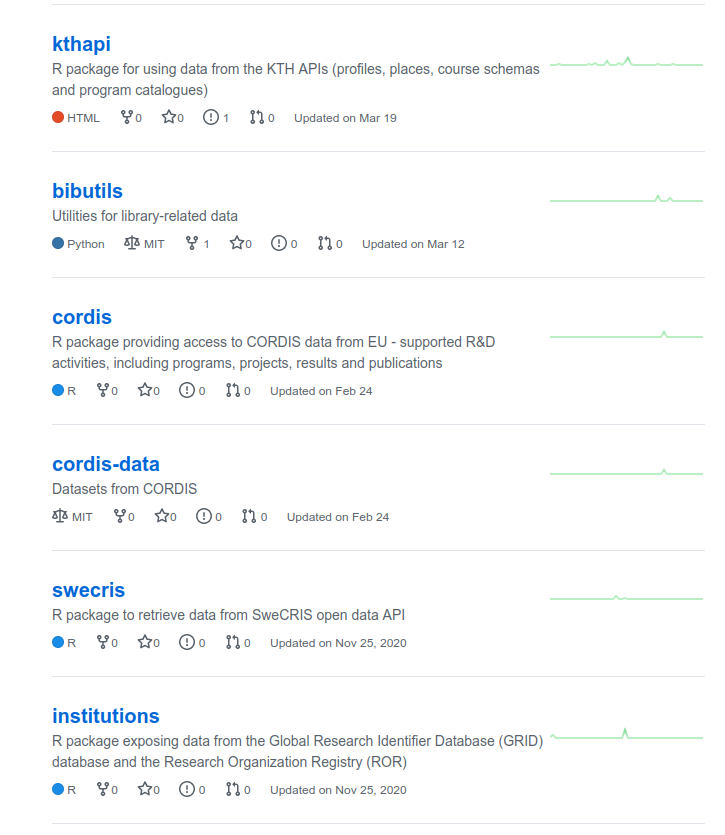

## Gruppdiskussion (15 min)

“Break-out rooms” i Zoom, med frågeställningar:

- **Vilken data använder du som vore intressant att samköra eller kombinera med det som visats?**
- **Vilka rutinmässiga underlag, analyser och rapporter producerar du som vore intressanta att automatisera?**

Grupperna modereras av Pernilla, Maria, Sofi, Agne, Gaël, Tobias och Markus.

> Förbered i gruppen en 3 min presentation av diskussionerna.

## Presentation av gruppdiskussion och summering

## Utblick - dataflöden & tjänster

- Vad är poängen med dataflöden?

[figure not shown]

  - transparens & tillgänglighet
  - reproducerbarhet
  - analytics
  - standardisering

## Exempel på dataflöde

- Infrastruktur

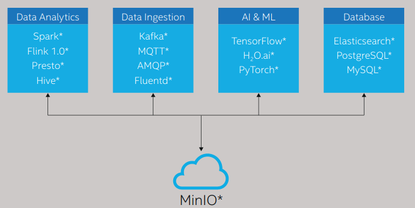

  - Datatillgänglighet
  - Mellanlager för data (S3)
  - Knyta samman datakällor

[figure not shown]

[figure not shown]

Källa: KTHB/PIMS